# The influence of time-of-day on estimates of taxonomic versus functional diversity in avian communities

Xxxxxxx Xxxxxxx, Xxxx X. Xxxxxxx

2023-06-02

```r
library(knitr)
knitr::opts_chunk$set(echo = TRUE)

rm(list = ls())

h <- taskCallbackManager()
h$add(function(expr, value, ok, visible) {
  options("prompt"=format(Sys.time(), "%H:%M:%S> "));
  return(TRUE) },
  name = "simpleHandler")

library(tidyverse)
library(ancends)
library(corrplot)
library(Momocs)
library(lubridate)
library(qpcR)
library(mgcv)
library(ggpubr)

select <- dplyr::select #masked by MASS

'%!in%' <- function(x,y)!('%in%'(x,y))

excna <- function(x){
  naid <- which(is.na(x))
  x[-naid]
}

exczero <- function(x){
  naid <- which(x == 0)
  x[-naid]
}
```

# Data

The data for this work are available online.

Point count results can be uploaded as

```r
nfk <- read_csv("https://raw.githubusercontent.com/*******x*******/**********/main/nfk_counts.csv")
```

Functional traits data are available at https://doi.org/10.xxxx/zenodo.xxxxxxx (v0) or

```r
traits <- read_csv("https://raw.githubusercontent.com/*******x*******/******/main/traits6_v0.csv")
```

# Distribution of sampled time of day

Overall distribution is sampled sufficiently evenly.

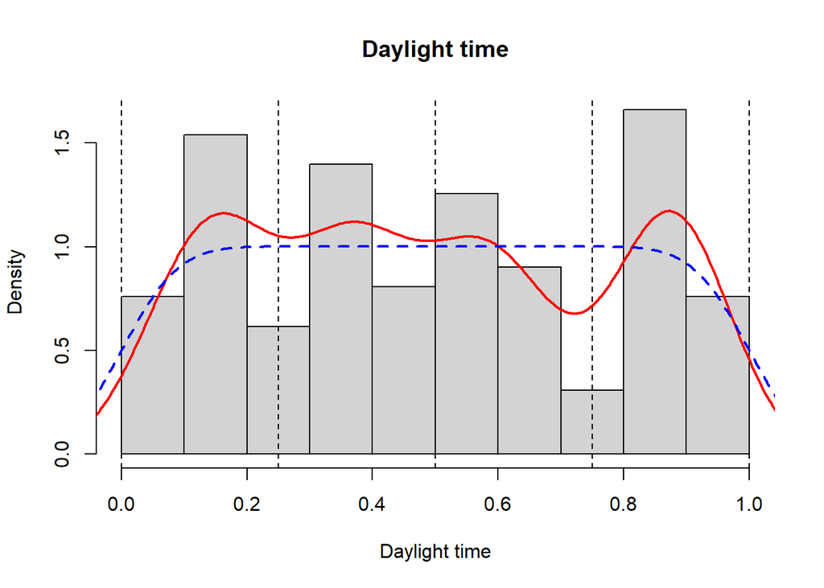

```r
hist(nfk$T, freq = F, main = "Daylight time", xlab = "Daylight time")
abline(v = c(0, 0.25, 0.5, 0.75, 1), lty = 2)
lines(density(nfk$T), col = "red", lwd = 2)
lines(density(rep(seq(0.05, 0.95, 0.1), 42)), col = "blue", lwd = 2, lty = 2)
```

Kolomogorov-Smirnov test to check whether the distribution differs from uniform:

```r
ks.test(nfk$T, "punif")
```

```
##
##  Asymptotic one-sample Kolmogorov-Smirnov test
##
## data:  nfk$T
## D = 0.051706, p-value = 0.2092
## alternative hypothesis: two-sided
```

Separate test for each individual location:

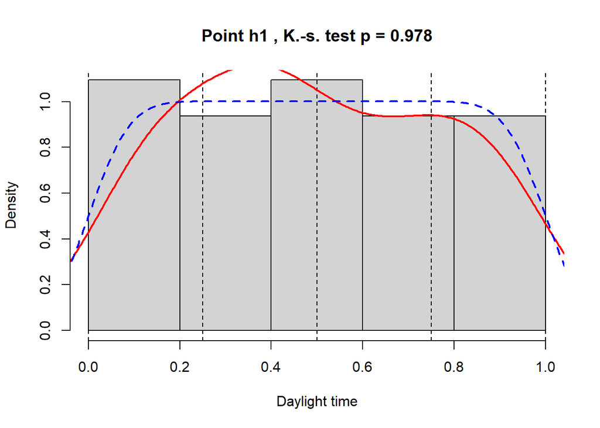

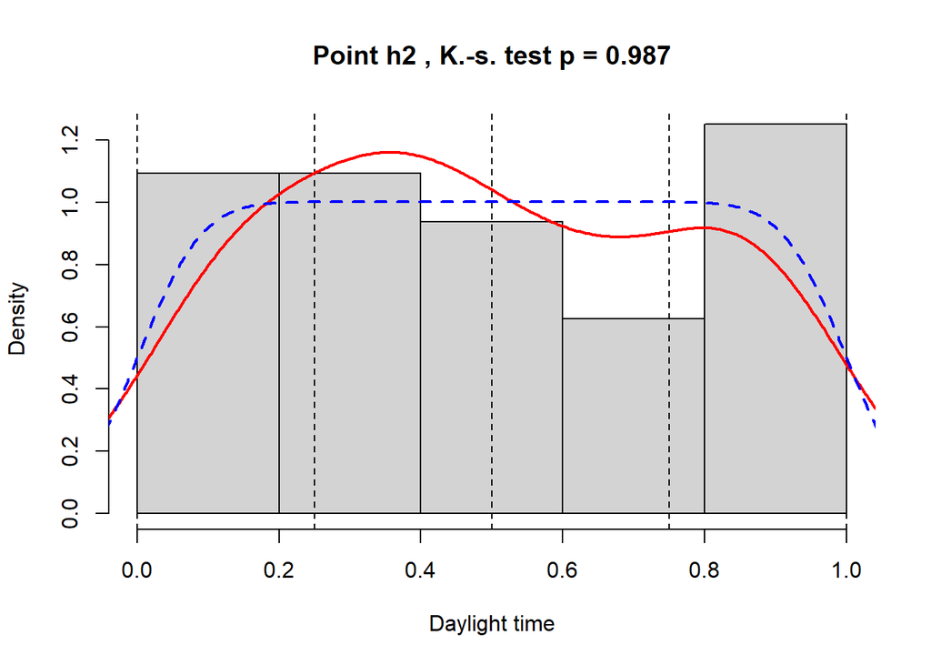

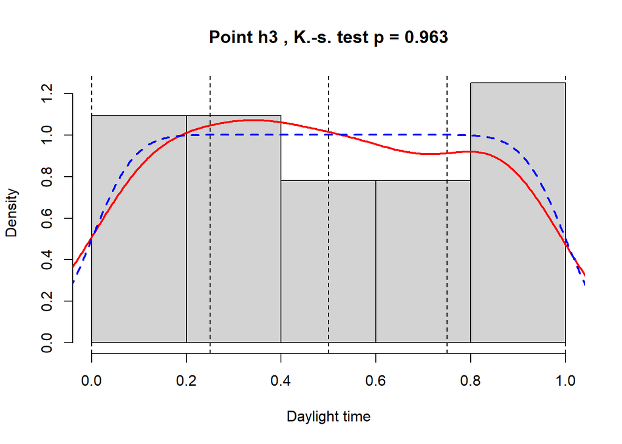

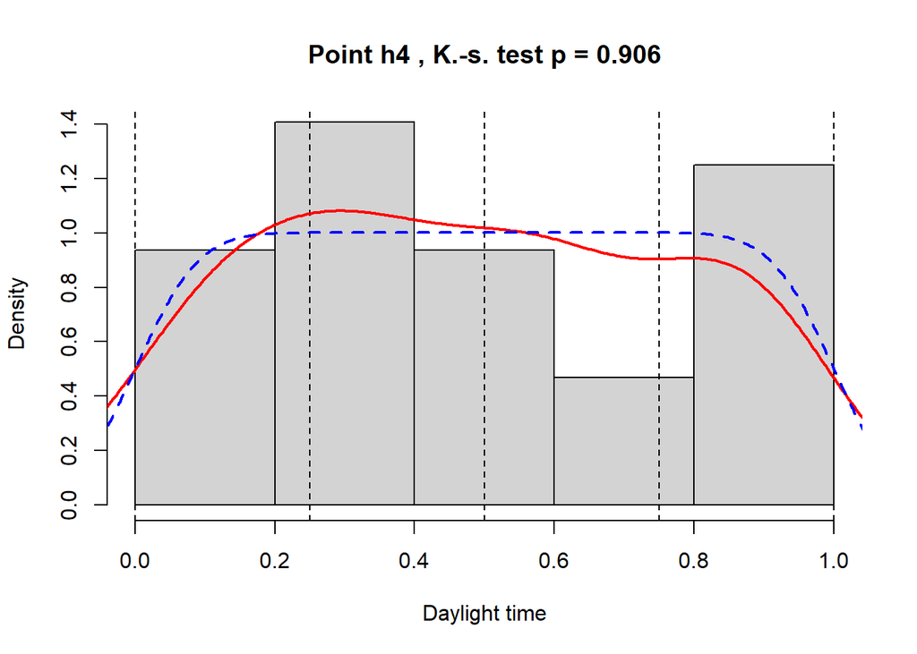

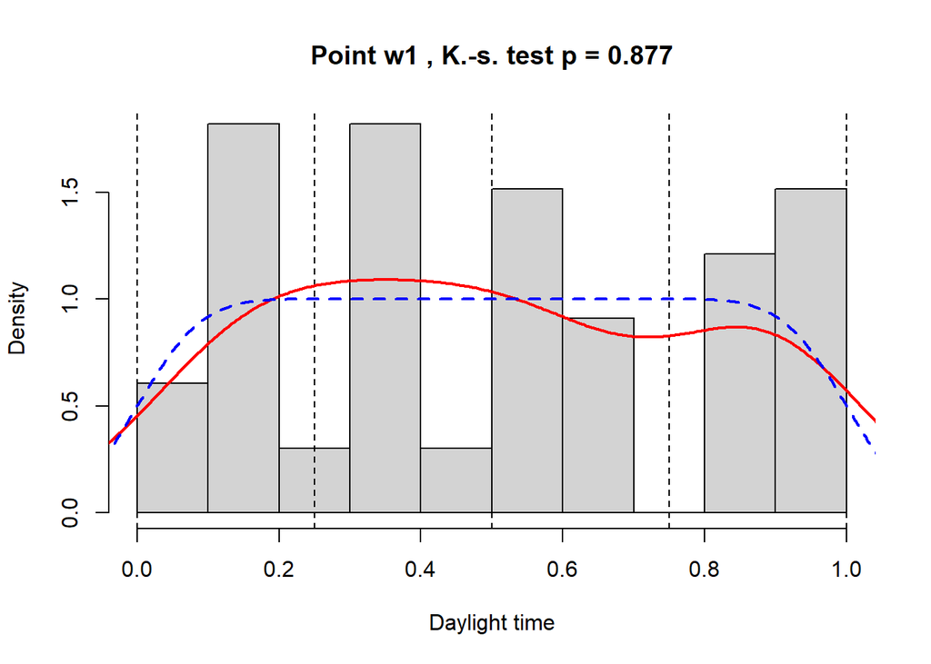

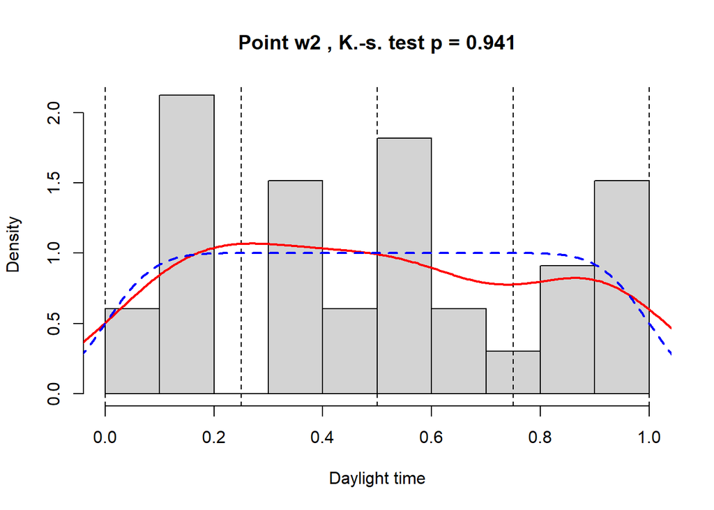

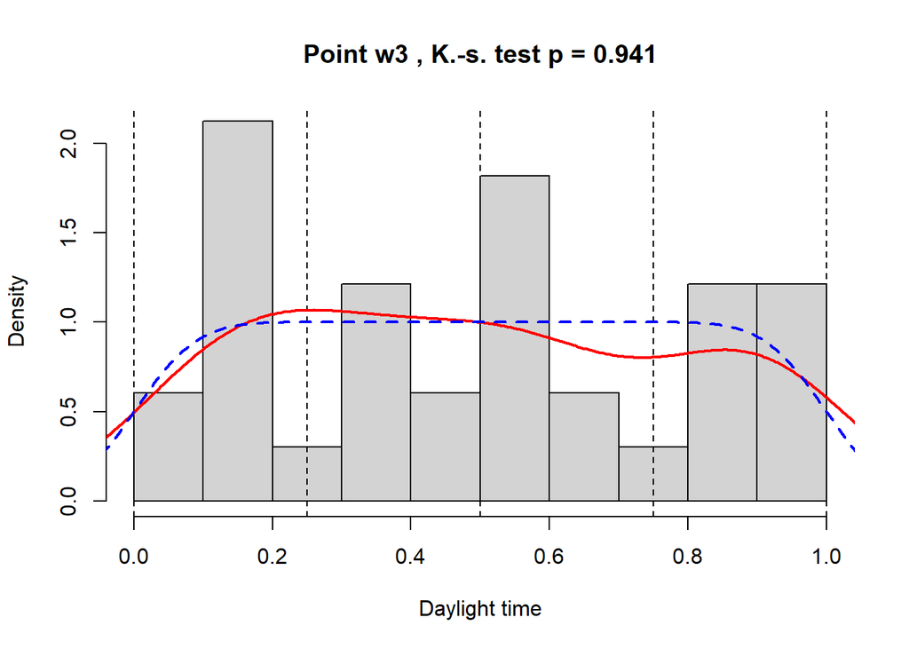

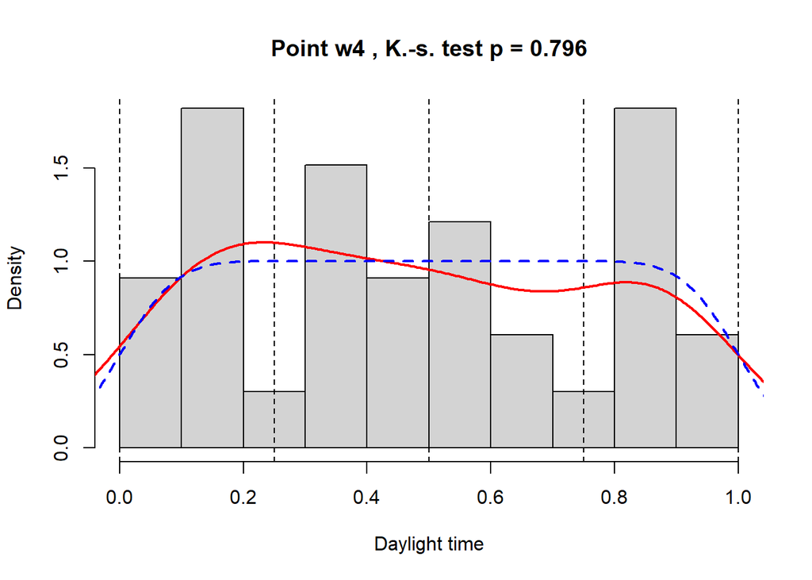

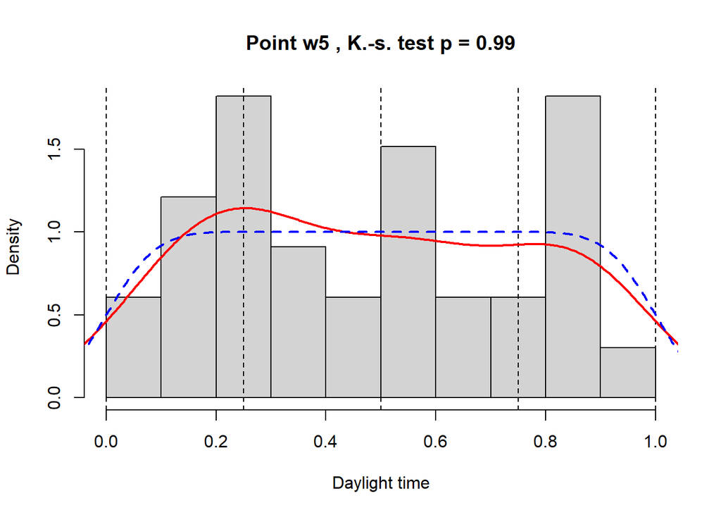

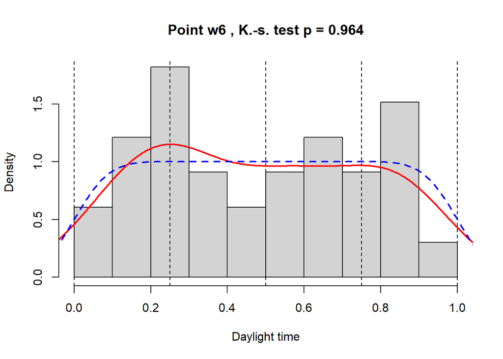

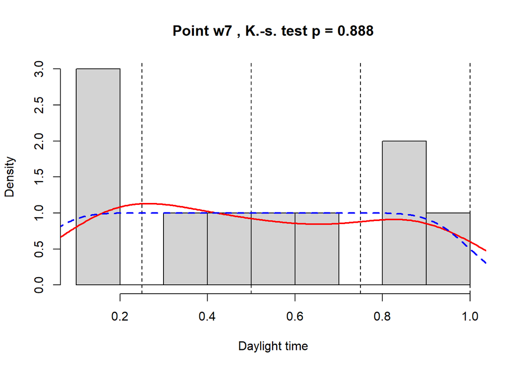

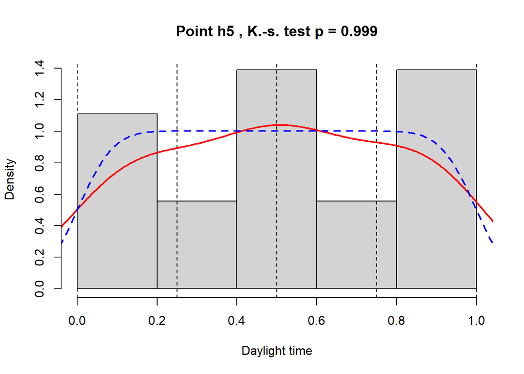

[3 more figures not shown]

```r
for (point in unique(nfk$Point)){
  subset_nfk <- nfk %>%
    filter(Point == point)
  hist(subset_nfk$T, freq = F,
       main = paste("Point", point, ", K.-s. test p =",
                    round(ks.test(subset_nfk$T, "punif")$p.value, digits = 3)),
       xlab = "Daylight time")
  abline(v = c(0, 0.25, 0.5, 0.75, 1), lty = 2)
  lines(density(subset_nfk$T), col = "red", lwd = 2)
  lines(density(rep(seq(0.05, 0.95, 0.1), 42)), col = "blue", lwd = 2, lty = 2)
}
```

# Estimation of taxonomic diversity

```r
nfk_N <- apply(nfk[,-c(1:8)], 1, function(x) sum(x, na.rm = T))
#transform abundances into species proportions
nfk_p <- as.data.frame(t(apply(nfk[,-c(1:8)], 1, function(x) x/sum(x, na.rm = T))))
#species richness
nfk_S <- apply(nfk_p, 1, function(x) length(excna(x)))
#shannon raw
nfk_shannon <- apply(nfk[,-c(1:8)], 1, function(x) shannon(excna(x)))
#shannon normalized
nfk_shannonS <- nfk_shannon/log(nfk_S)
nfk_shannonS <- ifelse(is.na(nfk_shannonS), 0, nfk_shannonS)
#hurlbert's pie
nfk_pie <- apply(nfk[,-c(1:8)], 1, function(x) hpie(excna(x)))
```

# Estimation of functional diversity

## Preparation for estimation of functional diversity

```r
#rewrite character variables as factors
traits <- traits %>%
  mutate(dev = as_factor(dev),
         naggr = as_factor(naggr),
         brsys = as_factor(brsys),
         nest = as_factor(nest),
         fc_categ = as_factor(fc_categ))

#Functional  TraitS indices, n=71
fts <- c(11,16,18,20,28,32,22,23,21,30,31,33,34,38,39,62,63,64,65,40:51,52:61,66:76,77:95)

trait_numind <- c("hwi", "mlife", "adsurviv", "matage", "suces", "bmass", "egglow",
                  "eggupp", "parasi", "attem",
                  "ndepen", "fpnoct", "fpdiur", "klepto") #names of numeric variables

nest <- matrix(c(0.0, 0.1, 0.2, 0.4, 0.45, 0.5, 0.55, 0.6, 0.65, 0.75, 0.8, 0.85, 0.9, 0.95,
                 0.1, 0, 0.25, 0.35, 0.4, 0.45, 0.55, 0.6, 0.65, 0.75, 0.8, 0.85, 0.9, 0.95,
                 0.2, 0.25, 0, 0.5, 0.55, 0.55, 0.3, 0.5, 0.6, 0.7, 0.75, 0.8, 0.85, 0.9,
                 0.4, 0.35, 0.5, 0, 0.15, 0.25, 0.6, 0.6, 0.6, 0.8, 0.8, 0.9, 0.9, 0.9,
                 0.45, 0.4, 0.55, 0.15, 0, 0.3, 0.6, 0.6, 0.6, 0.8, 0.8, 0.8, 0.9, 0.9,
                 0.5, 0.45, 0.55, 0.25, 0.3, 0, 0.6, 0.5, 0.4, 0.4, 0.35, 0.35, 0.7, 0.7,
                 0.55, 0.55, 0.3, 0.6, 0.6, 0.6, 0, 0.2, 0.3, 0.6, 0.6, 0.7, 0.8, 0.9,
                 0.6, 0.6, 0.5, 0.6, 0.6, 0.5, 0.2, 0, 0.15, 0.5, 0.7, 0.8, 0.8, 0.9,
                 0.65, 0.65, 0.6, 0.6, 0.6, 0.4, 0.3, 0.15, 0, 0.4, 0.5, 0.6, 0.7, 0.8,
                 0.75, 0.75, 0.7, 0.8, 0.8, 0.4, 0.6, 0.5, 0.4, 0, 0.5, 0.5, 0.6, 0.6,
                 0.8, 0.8, 0.75, 0.8, 0.8, 0.35, 0.6, 0.7, 0.5, 0.5, 0, 0.2, 0.15, 0.6,
                 0.85, 0.85, 0.8, 0.9, 0.8, 0.35, 0.7, 0.8, 0.6, 0.5, 0.2, 0, 0.1, 0.6,
                 0.9, 0.9, 0.85, 0.9, 0.9, 0.7, 0.8, 0.8, 0.7, 0.6, 0.15, 0.1, 0, 0.6,
                 0.95, 0.95, 0.9, 0.9, 0.9, 0.7, 0.9, 0.9, 0.8, 0.6, 0.6, 0.6, 0.6, 0),
               ncol = 14, nrow = 14, byrow = T)
colnames(nest) <- c("no", "paras", "scrape", "crevice", "burrow", "cavity", "platform",
                    "saucer", "cup",
                    "sphere", "chamber", "oven", "gourd", "pend")
rownames(nest) <- c("no", "paras", "scrape", "crevice", "burrow", "cavity", "platform",
                    "saucer", "cup",
                    "sphere", "chamber", "oven", "gourd", "pend")
#matrix of categories distance for nest type

dev <- matrix(c(0.0, 0.1, 0.2, 0.4, 0.6, 0.8, 1.0,
                0.1, 0.0, 0.1, 0.3, 0.5, 0.7, 0.9,
                0.2, 0.1, 0.0, 0.2, 0.4, 0.6, 0.8,
                0.4, 0.3, 0.2, 0.0, 0.2, 0.4, 0.6,
                0.6, 0.5, 0.4, 0.2, 0.0, 0.2, 0.4,
                0.8, 0.7, 0.6, 0.4, 0.2, 0.0, 0.2,
                1.0, 0.9, 0.8, 0.6, 0.4, 0.2, 0.0),
              ncol = 7, nrow = 7, byrow = T)
colnames(dev) <- c("pre2", "pre3", "pre4", "semipre", "semialt1", "semialt2", "alt")
rownames(dev) <- c("pre2", "pre3", "pre4", "semipre", "semialt1", "semialt2", "alt")
#same for hatching development

brsys <- matrix(c(0, 0.25, 0.4, 0.6, 0.8, 0.8, 0.7,
                  0.25, 0, 0.3, 0.3, 0.5, 0.5, 0.9,
                  0.4, 0.3, 0, 0.25, 0.4, 0.4, 1,
                  0.6, 0.3, 0.25, 0, 0.5, 0.5, 0.9,
                  0.8, 0.5, 0.4, 0.5, 0, 0.25, 0.6,
                  0.8, 0.5, 0.4, 0.5, 0.25, 0, 0.6,
                  0.7, 0.9, 1, 0.6, 0.6, 0.6, 0),
                nrow = 7, ncol = 7, byrow = T)
colnames(brsys) <- c("coop", "polygam", "promisc", "lek", "polyand", "polygyn", "monog")
rownames(brsys) <- c("coop", "polygam", "promisc", "lek", "polyand", "polygyn", "monog")
#same for breeding system

fc_categ <- matrix(c(0, 0.6, 0.4, 0.2, 0.8,
                     0.6, 0, 0.5, 0.7, 0.2,
                     0.4, 0.5, 0, 0.5, 0.4,
                     0.2, 0.7, 0.5, 0, 0.3,
                     0.8, 0.2, 0.4, 0.3, 0),
                   nrow = 5, ncol = 5, byrow = T)
colnames(fc_categ) <- c("FruiNect", "Invertebrate", "Omnivore", "PlantSeed", "VertFishScav")
rownames(fc_categ) <- c("FruiNect", "Invertebrate", "Omnivore", "PlantSeed", "VertFishScav")
#same for diet categories

naggr <- matrix(c(0, 0.5, 1,
                  0.5, 0, 0.5,
                  1, 0.5, 0),
                nrow = 3, ncol = 3, byrow = T)
colnames(naggr) <- c(1, 2, 3)
rownames(naggr) <- c(1, 2, 3) #same for nest aggregation level

trait_catmxs <- list(nest = nest, dev = dev, brsys = brsys, fc_categ = fc_categ, naggr = naggr)
trait_catind <- names(trait_catmxs)

trait_grind <- list(ns = c("nsbank", "nsgroun", "nsgrass", "nsclif", "nsbuild", "nsshru",
                           "nsdeci", "nsconi",
                           "nssnag", "nscact", "nstang", "nsfloat"),
                    fs = c("fsmud", "fswatb", "fswata", "fstimb", "fsgroun", "fsunder",
                           "fsmidhigh", "fscanopy",
                           "fsaerial", "fsdump"),
                    fc = c("fcinvert", "fcvend", "fcvect", "fcfish", "fcunk", "fcscav",
                           "fcfruit", "fcnect", "fcseed",
                           "fcgree", "fcleft"),
                    fm = c("fmdig", "fmgrgl", "fmfogl", "fmbagl", "fmhogl", "fmhopo",
                           "fmhawk", "fmaero", "fmapur",
                           "fmswoo", "fmhipa", "fmlopa", "fmhidi", "fmskim", "fmsdiv",
                           "fmsdip", "fmdabb", "fmstal",
                           "fmprob")) #grouped variables
```

## Estimating species distinctiveness in the regional pool

```r
#estimation of "regional" (e.g., within the study area) abundances of each species
#as sum of mean abundances (mean as an expectation of Poisson distribution, assuming that
# species abundances is a Poisson process)
# of species at each point
regional_species_abun <- nfk[,-c(1:5, 7:8)] %>%
  group_by(Point) %>%
  summarise_all(mean, na.rm = T) %>%
  select(-`Point`) %>%
  apply(MARGIN = 2, FUN = function(x) sum(excna(x)))

#calculation of a centroid
centroid <- function(x, weighted = F, weights){
  if (!weighted){
      l <- vector(mode = "list", length = ncol(x))
      for (j in 1:ncol(x)){
        if (is.numeric(x[j][[1]])){
          l[[j]] <- mean(x[j][[1]])
        }else if (is.factor(x[j][[1]])){
          l[[j]] <- summary(x[j][[1]])/nrow(x)
        }
      }
  } else {
    if (missing(weights)){
      warning("weights are not provided, assuming equal weights")
      weights <- rep(1, nrow(x))
    }
      if (length(weights) != nrow(x)){
        stop("length of weights differs from number of rows in x")
      }
    w <- weights/sum(weights)
      l <- vector(mode = "list", length = ncol(x))
        for (j in 1:ncol(x)){
          if (is.numeric(x[j][[1]])){
            l[[j]] <- sum(w*x[j][[1]])
          }else if (is.factor(x[j][[1]])){
            lvls <- levels(x[j][[1]])
            l[[j]] <- sapply(lvls, function(lvl){
              sum(w[which(x[j][[1]] == lvl)])
            })
          }
        }
  }
  names(l) <- colnames(x)
  return(l)
}

#subsetting traits of all North American species to those observed
nfk_traits <- traits %>%
  filter(proj_id %in% names(regional_species_abun))

#arranging regional_species_abun in the same order
regional_species_abun <- regional_species_abun[as.character(nfk_traits$proj_id)]

nfk_centroid_weighted <- centroid(nfk_traits[, fts],#again, fts is index of columns in
                                  # traits that correspond to the actual traits,
                                  weighted = T, weights = regional_species_abun)

nfk_centroid_unweighted <- centroid(nfk_traits[, fts])
```

Both weighted and unweighted centroids are stored as lists to account for their complex nature.

Now, to use any dimension technique, one needs to estimate species distinctiveness from the centroid.

```r
distinct <- function(x, cen, numind, catind, catmxs, grind){
  #x : dataframe with cols-traits and rows-species
  #cen : list with names-traits and values {mean for numeric, vector of freqs
  # for categorical}
  #numind : vector of numeric variables indices or names
  #catind : vector of categorical variables indices or names
  #catmxs : named (=traits) list of distance matrices for categorical variables
  #grind : named (=name of group) list of names of trait variables {e.g., ns: nsbank,
  # nsground,...}
  #
  #helpers
  cat_dist <- function(value, mx, freqs){
    #calculate distance between categorical trait values based on a similarity matrix
    distances <- mx[, which(colnames(mx) == value)] # distances between the value and all
    #other possible values
    ws <- matrix(NA, ncol = 2, nrow = length(freqs))
    colnames(ws) <- c("distance", "weight")
    #rownames(ws) <- colnames(mx)
    rownames(ws) <- names(freqs)
    for (cat in rownames(ws)){
      ws[cat,] <- c(distances[cat], ifelse(cat == value, 0, freqs[cat]))
    } # two arranged vectors of distances and weights of the categories (self-similarity
    # means 0 distinctiveness)
    sum(ws[,1]*ws[,2]) / max(ws[,1]) # normalized by the maximum possible distinctiveness
  }
  group_overlap <- function(vec, cen){
    #calculate overlap between two discrete distributions
    vec <- vec/sum(vec)
    cen <- unlist(cen)/sum(unlist(cen))
    overlap <- sapply(1:length(vec), function(i) min(vec[i], cen[i]))
    sum(overlap)
  }
  #
  #numeric variables
  numvals <- matrix(NA, nrow = nrow(x), ncol = length(numind))
  colnames(numvals) <- numind
  rownames(numvals) <- rownames(x)
  for (trait in numind){
    numvals[,trait] <- sapply(x[,trait], function(taxa_value){
      abs(taxa_value - unlist(cen[trait]))
    })
  }
  rownames(numvals) <- rownames(x)

  #categorical variables
  catvals <- matrix(NA, nrow = nrow(x), ncol = length(catind))
  colnames(catvals) <- catind
  rownames(catvals) <- rownames(x)
  for (trait in catind){
    mx <- catmxs[trait][[1]]
    sp <- 1
    for (taxa_value in x[,trait]){
      catvals[sp, trait] <- cat_dist(value = taxa_value,
                                     mx = mx,
                                     freqs = cen[trait][[1]])
      sp <- sp+1
    }
  }
  #grouped variables
  grvals <- matrix(NA, nrow = nrow(x), ncol = length(grind))
  rownames(grvals) <- rownames(x)
  colnames(grvals) <- names(grind)
  for (trait in names(grind)){
    traits <- grind[trait][[1]]
    for (taxa in rownames(x)){
      grvals[taxa, trait] <- group_overlap(vec = unlist(x[taxa, traits]),
                                           cen = unlist(cen[traits]))
    }
  }

  grdist <- matrix(NA, nrow = nrow(x), ncol = length(grind))
  rownames(grdist) <- rownames(x)
  colnames(grdist) <- names(grind)
  mo <- NA
  for (trait in names(grind)){
    mo <- max(grvals[,trait])
    grdist[,trait] <- 1-(grvals[,trait]/mo)
  }
  cbind(numvals, catvals, grdist)
}

#scale since units differ among traits
td_weighted <- distinct(x = as.data.frame(nfk_traits),
                        cen = nfk_centroid_weighted,
                        numind = trait_numind,
                        catind = trait_catind,
                        grind = trait_grind,
                        catmxs = trait_catmxs) %>%
  scale()
td_unweighted <- distinct(x = as.data.frame(nfk_traits),
                        cen = nfk_centroid_unweighted,
                        numind = trait_numind,
                        catind = trait_catind,
                        grind = trait_grind,
                        catmxs = trait_catmxs) %>%
  scale()
```

Now, one can apply PCA to distinctiveness to reduce number of dimensions. Although it is applied to trait distinctiveness rather to the raw trait values, it is still a valid approach because (1) individual trait distinctiveness is a metric of deviation of a species along a singular trait axis, and (2) it allows PCA deal with non-metric raw traits.

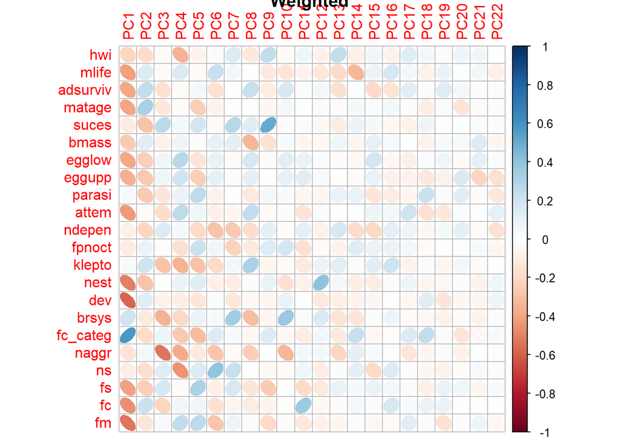

```r
td_pca_weighted <- prcomp(td_weighted[,!is.na(apply(td_weighted, 2, var))])
td_pca_unweighted <- prcomp(td_unweighted[,!is.na(apply(td_unweighted, 2, var))])

corrplot(cor(td_weighted[,!is.na(apply(td_weighted, 2, var))],
             td_pca_weighted$x, method = "kendall"), title = "Weighted", method = "ellipse")
```

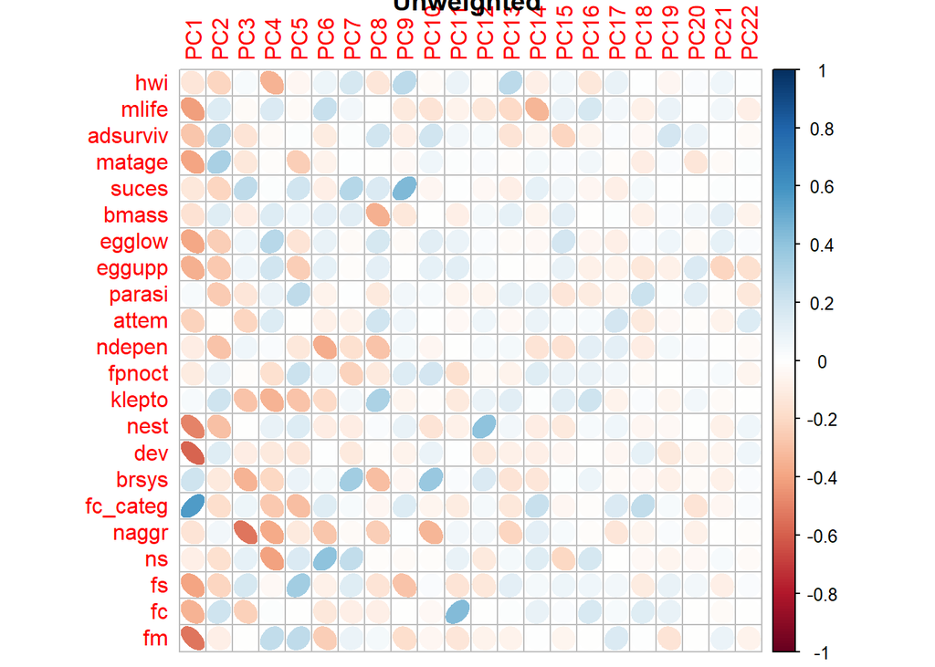

```r
corrplot(cor(td_unweighted[,!is.na(apply(td_unweighted, 2, var))],
             td_pca_weighted$x, method = "kendall"), title = "Unweighted", method = "ellipse")
```

Both weighted and unweighted by abundance approaches produce similar results. One could infer several principal components corresponding to species’ ecological features:

- `PC1` is mostly correlated with `mlife` (maximum life longevity), `matage` (minimum mating age), `dev` (development stage at hatching), and `nest` (nest type), representing **reproductive biology**;
- `PC2` is correlated with `egglow`/`eggupp` (clutch size), `parasi` (nest parasitism), `matage` (minimum mating age), and `ndepen` (degree of dependency on other species’ activity to build a nest), representing **nesting traits**;
- `PC3` is correlated with `suces` (nesting success), `naggr` (nest aggregation), and `brsys` (breeding system), that might correspond to **species’ degree of sociality**;
- `PC4` is correlated with `hwi` (hand-wing index), `ns` (nest substrate), and `klepto` (kleptoparasitism), all of which point at species’ movement ecology and habitat fidelity, therefore, relate to **dispersal ecology**;
- `PC5` is correlated with `fs` (feeding substrate) and `fm` (feeding methods), representing **foraging ecology**;
- `PC6` is correlated with `ndepen` (nesting dependency on other species), `naggr` (nesting aggregation), and `ns` (nest substrate), which may represent **interspecific nesting requirements**;
- `PC11` is correlated with `fc` (feeding category), which represents species’ **diet**.

All together, these PCs accumulate approximately half of trait variance:

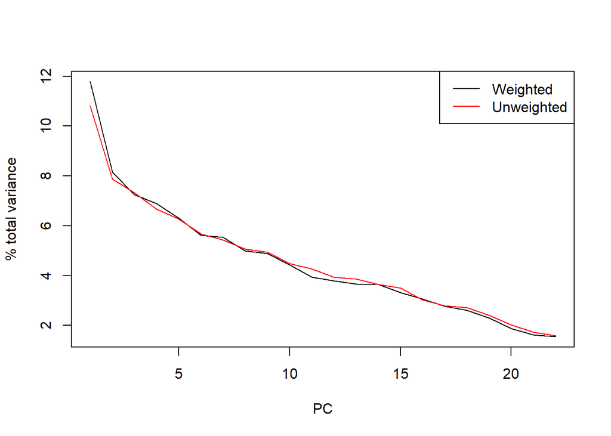

```r
(td_pca_weighted$sdev*100/sum(td_pca_weighted$sdev)) %>% plot(type = "l", xlab = "PC",
                                                              ylab = "% total variance")
(td_pca_unweighted$sdev*100/sum(td_pca_unweighted$sdev)) %>% lines(col = "red")
legend("topright", legend=c("Weighted", "Unweighted"), col=c("black", "red"),
       lty = c(1, 1))
```

```r
paste("PCs 1, 2, 3, 4, 5, 6, and 11 account for",
      ((td_pca_weighted$sdev*100/sum(td_pca_weighted$sdev))[c(1:6, 11)] %>% sum() %>%
         round(digits = 2)), "% of variance in weighted trait distinctiveness")
```

```
## [1] "PCs 1, 2, 3, 4, 5, 6, and 11 account for 49.94 % of variance in weighted trait distinctiveness"
```

```r
paste("PCs 1, 2, 3, 4, 5, 6, and 11 account for",
      ((td_pca_unweighted$sdev*100/sum(td_pca_unweighted$sdev))[c(1:6, 11)] %>% sum() %>%
         round(digits = 2)), "% of variance in unweighted trait distinctiveness")
```

```
## [1] "PCs 1, 2, 3, 4, 5, 6, and 11 account for 48.89 % of variance in unweighted trait distinctiveness"
```

Now we write these PCs of each species:

```r
fdpca_weighted <- td_pca_weighted$x[,c(1:6, 11)]
fdpca_weighted <- fdpca_weighted %>%
  as_tibble() %>%
  mutate(proj_id = nfk_traits$proj_id %>% unlist(),
         reproduction = PC1,
         nesting = PC2,
         sociality = PC3,
         dispersal = PC4,
         feeding = PC5,
         interspecific = PC6,
         diet = PC11) %>%
  select(proj_id, reproduction, nesting, sociality, dispersal, feeding, interspecific, diet)
fdpca_unweighted <- td_pca_unweighted$x[,c(1:6, 11)]
fdpca_unweighted <- fdpca_unweighted %>%
  as_tibble() %>%
  mutate(proj_id = nfk_traits$proj_id %>% unlist(),
         reproduction = PC1,
         nesting = PC2,
         sociality = PC3,
         dispersal = PC4,
         feeding = PC5,
         interspecific = PC6,
         diet = PC11) %>%
  select(proj_id, reproduction, nesting, sociality, dispersal, feeding, interspecific, diet)
```

## Functional diversity metrics

### Functional richness

Functional richness is defined as convex hull volume of a community in multidimensional space of functional traits.

```r
frich <- function(taxa, traits){
  traits %>%
    filter(proj_id %in% taxa) %>%
    select(-proj_id) %>%
    as.data.frame() %>%
    prcomp() %>%
    as_PCA() %>%
    get_chull_volume()
}
nfk_frich <- sapply(1:nrow(nfk),
                    function(i){
                      taxa_list <- nfk[i, -c(1:8)][!is.na(nfk[i, -c(1:8)] %>% unlist())] %>%
                        colnames()
                      if(length(taxa_list) < 4){ #>=4 points needed to build a convex hull
                        return(0)
                      }else{
                        return(frich(taxa_list, fdpca_weighted))
                      }
                    })
```

### Functional evenness

Functional evenness is defined ([Villéger et al. 2008](https://doi.org/10.1890/07-1206.1)) as
$$\text{FEve} =
\frac{\sum\limits_{l=1}^{S-1}\min \left( \left[ \frac{\frac{d(i, j)}{w_i
+ w_j}}{\sum_{l = 1}^{S-1} \frac{d(i, j)}{w_i + w_j}} \right], \left[
\frac{1}{S-1} \right] \right) - \frac{1}{S-1}}{1 -
\frac{1}{S-1}}$$

where $l$ is a branch of a length $d(i, j)$ between species $i$ and $j$ in a trait space.

```r
feve <- function(traits, w){
  if (nrow(traits) != length(w)){
    stop("number of objects diesn't equal number of weights")
  }
  if (nrow(traits) <= 1){
    return(0)
  }else{
    w <- w/sum(w)
    traits <- as.data.frame(traits)
    distmx <- dist(traits) %>% as.matrix()
    diag(distmx) <- Inf
    #distmx[upper.tri(distmx)] <- 9999
    distmx <- distmx[-1,]
    if (is.null(dim(distmx))){
      branch_distances <- min(distmx)
      branch_weights <- sum(w)
    }else{
      branch_distances <- apply(distmx, 1, min) %>% unlist()
      branch_coordinates <- apply(distmx, 1, function(x) which(x == min(x))[1])
      branch_weights <- sapply(1:length(branch_coordinates),
                             function(i){
                               w[names(branch_coordinates)[i]] + w[branch_coordinates[i]]
                             })
    }
    ew <- branch_distances/branch_weights
    pew <- ew/sum(ew)
    S <- ifelse(nrow(traits) > 2, nrow(traits), nrow(traits)+1)
    feve <- (sum(sapply(pew, function(pew_l){
      min(pew_l, 1/(S-1))
    } )) - (1/(S-1))) / (1 - (1 / (S-1)))
    return(feve)
  }
}

nfk_feve <- sapply(1:nrow(nfk),
                    function(i){
                      taxa_abun <- nfk[i, -c(1:8)][!is.na(nfk[i, -c(1:8)] %>% unlist())]
                      taxa_list <- taxa_abun %>% colnames()
                      taxa_traits <- fdpca_unweighted %>% scale() %>% as.data.frame()
                      rownames(taxa_traits) <- fdpca_unweighted$proj_id
                      taxa_traits <- taxa_traits[taxa_list, -1]
                      return(feve(traits = taxa_traits, w = unlist(taxa_abun)))
                    })
```

### Rao’s quadratic entropy

Rao’s quadratic entropy ([Pavoine et al. 2005](https://doi.org/10.1016/j.tpb.2005.01.004)) can be calculated as
$$\text{H}_D(p) = \sum\limits_{i=1}^S
\sum\limits_{j = 1}^S p_i p_j d(i, j)$$

where $d(i, j)$ is the distance between species $i$ and $j$ in functional space.

```r
rao <- function(traits, abun){
  if (nrow(traits) != length(abun)){
    stop("number of objects doesn't equal number of weights")
  }
  if (nrow(traits) <= 1){
    return(0)
  }else{
    w <- abun/sum(abun)
    traits <- as.data.frame(traits) %>% scale() %>% as.data.frame()
    distmx <- dist(traits) %>% as.matrix()
    entropy <- numeric(0)
    for (i in 1:(nrow(traits)-1)){
      for (j in (i+1):nrow(traits)){
        entropy <- c(entropy,
                     w[i]*w[j]*distmx[i, j])
      }
    }
  return(sum(entropy))
  }
}

nfk_rao <- sapply(1:nrow(nfk),
                    function(i){
                      taxa_abun <- nfk[i, -c(1:8)][!is.na(nfk[i, -c(1:8)] %>% unlist())]
                      taxa_list <- taxa_abun %>% colnames()
                      taxa_traits <- fdpca_unweighted %>% as.data.frame()
                      rownames(taxa_traits) <- fdpca_unweighted$proj_id
                      taxa_traits <- taxa_traits[taxa_list, -1]
                      return(rao(traits = taxa_traits, abun = unlist(taxa_abun)))
                    })
```

### Weighted mean distinctiveness

Previous metrics assign zero values to observations of single species, even if such taxa are functionally distinctive in the regional pool. To account for that, weighted by abundance functional distinctiveness could also be used.

```r
nfk_fdist <- apply(scale(fdpca_unweighted[,-1]), 1, function(x) sqrt(mean(pnorm(x)^2)))
names(nfk_fdist) <- fdpca_unweighted[,1] %>% unlist()

pfd <- function(fdist, w){
  fd <- unlist(fdist)
  fdnames <- names(fd)
  w <- unlist(w)[fdnames]
  w <- w/sum(w)
  return(sum(fd*w))
}

nfk_pfd <- sapply(1:nrow(nfk),
                    function(i){
                      taxa_abun <- nfk[i, -c(1:8)][!is.na(nfk[i, -c(1:8)] %>% unlist())]
                      taxa_list <- taxa_abun %>% colnames()
                      taxa_fdist <- nfk_fdist[taxa_list]
                      return(pfd(fdist = taxa_fdist, w = taxa_abun))
                    })
```

# Analysis

## Compiling prepared dataframe

```r
nfk_div <- nfk %>%
  select(Date, #date, m/d/yyyy
         Time, #local time
         `T`, #time-of-day between sunrise (0) and sunset (1)
         Per, #period of day: morning (m), noon (n), afternoon (a), or evening (e)
         Dec, #decade from start of the study
         Point, #obsevation location
         W, #wind from still (0) to storm (10)
         Cloud #cloud cover, %(100^-1)
         ) %>%
  mutate(Day = (mdy(Date) - ymd("2021-03-07")) %>% as.numeric()) %>% #day since beginning
  # of the study, reqs lubridate::*
  mutate(Daytime = `T`) %>% select(-`T`) %>%
  mutate(sprich = nfk_S, #species richness
         shannon = nfk_shannon, #raw Shannon index
         std_shannon = nfk_shannonS, #standardized Shannon index
         pie = nfk_pie, #Hurlbert's probability of interspecific encounter
         frich = nfk_frich, #functional richness
         pfd = nfk_pfd, #weighted mean functional distinctiveness
         feve = nfk_feve, #functional evenness
         rao = nfk_rao #Rao's quadratic entropy
         ) %>%
  filter(sprich >= 4) #threshold of 4 species is minimum to calculate functional richness
paste("4 or more species were observed in", nrow(nfk_div), "out of", nrow(nfk), "counts")
```

```
## [1] "4 or more species were observed in 367 out of 422 counts"
```

## Distribution of diversity metrics

```r
metrics_shapiro <- tibble(Metric = c("Species richness",
                                     "Shannon index",
                                     "Standardized Shannon",
                                     "Hurlbert's PIE",
                                     "Functional richness",
                                     "Mean distinctiveness",
                                     "Functional evenness",
                                     "Rao's entropy"),
                          W = c(shapiro.test(nfk_div$sprich)$statistic,
                                shapiro.test(nfk_div$shannon)$statistic,
                                shapiro.test(nfk_div$std_shannon)$statistic,
                                shapiro.test(nfk_div$pie)$statistic,
                                shapiro.test(nfk_div$frich)$statistic,
                                shapiro.test(nfk_div$pfd)$statistic,
                                shapiro.test(nfk_div$feve)$statistic,
                                shapiro.test(nfk_div$rao)$statistic),
                          p = c(shapiro.test(nfk_div$sprich)$p.value,
                                shapiro.test(nfk_div$shannon)$p.value,
                                shapiro.test(nfk_div$std_shannon)$p.value,
                                shapiro.test(nfk_div$pie)$p.value,
                                shapiro.test(nfk_div$frich)$p.value,
                                shapiro.test(nfk_div$pfd)$p.value,
                                shapiro.test(nfk_div$feve)$p.value,
                                shapiro.test(nfk_div$rao)$p.value))
write_csv(metrics_shapiro, "metrics_shapiro.csv")
```

Shapiro-Wilk test results for the metrics.

| Metric | W | p |
| --- | --- | --- |
| Species richness | 0.949 | 0.000 |
| Shannon index | 0.986 | 0.001 |
| Standardized Shannon | 0.668 | 0.000 |
| Hurlbert’s PIE | 0.781 | 0.000 |
| Functional richness | 0.803 | 0.000 |
| Mean distinctiveness | 0.992 | 0.061 |
| Functional evenness | 0.979 | 0.000 |
| Rao’s entropy | 0.970 | 0.000 |

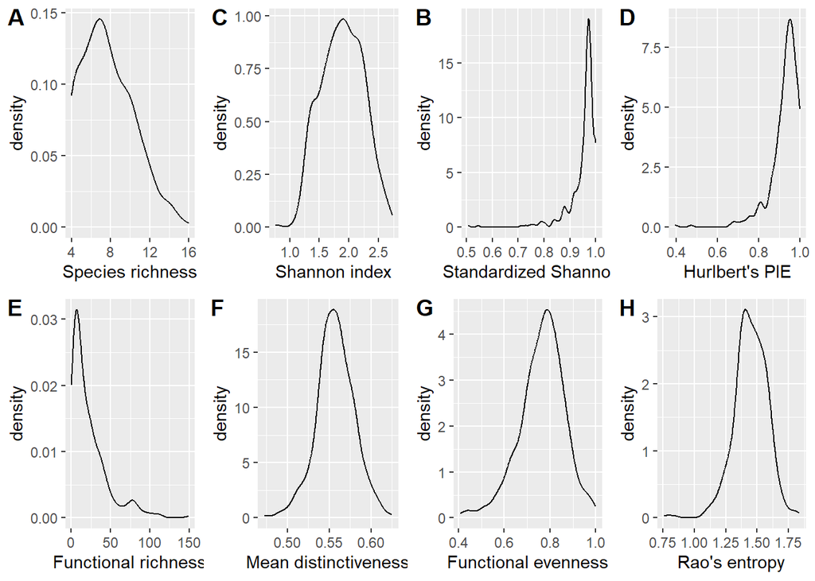

```r
ggarrange(plotlist = list(nfk_div %>%
                            ggplot(aes(x = sprich))+
                            geom_density()+
                            xlab("Species richness"),
                          nfk_div %>%
                            ggplot(aes(x = shannon))+
                            geom_density()+
                            xlab("Shannon index"),
                          nfk_div %>%
                            ggplot(aes(x = std_shannon))+
                            geom_density()+
                            xlab("Standardized Shannon"),
                          nfk_div %>%
                            ggplot(aes(x = pie))+
                            geom_density()+
                            xlab("Hurlbert's PIE"),
                          nfk_div %>%
                            ggplot(aes(x = frich))+
                            geom_density()+
                            xlab("Functional richness"),
                          nfk_div %>%
                            ggplot(aes(x = pfd))+
                            geom_density()+
                            xlab("Mean distinctiveness"),
                          nfk_div %>%
                            ggplot(aes(x = feve))+
                            geom_density()+
                            xlab("Functional evenness"),
                          nfk_div %>%
                            ggplot(aes(x = rao))+
                            geom_density()+
                            xlab("Rao's entropy")),
  labels = c("A", "C", "B", "D", "E", "F", "G", "H"),
  ncol = 4, nrow = 2)
```

## Covariation between diversity metrics

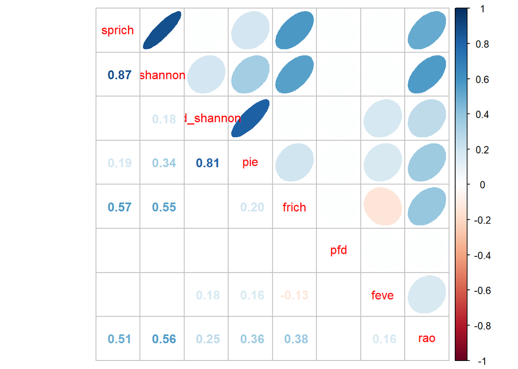

```r
div_cor <- cor(nfk_div[, -c(1:9)], nfk_div[, -c(1:9)], method = "kendall")
div_cor_p <- cor.mtest(nfk_div[, -c(1:9)], method = "kendall")$p
div_cor[which(div_cor_p > 0.01)] <- 0
corrplot.mixed(div_cor, lower = "number", upper = 'ellipse')
```

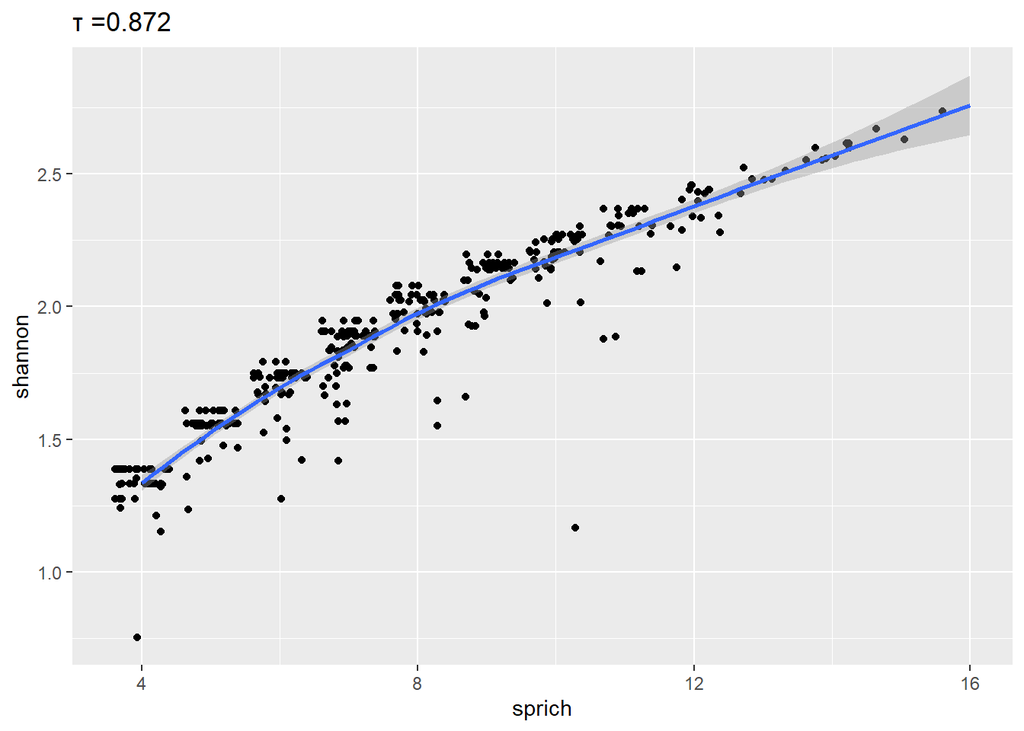

```r
nfk_div %>%
  filter(sprich > 1) %>%
  ggplot(aes(x = sprich, y = shannon))+
  geom_jitter()+
  geom_smooth()+
  labs(title = paste("\u03c4 =", round(cor(nfk_div$sprich,
                                        nfk_div$shannon,
                                        method = "kendall"), 3),
                     sep = ""))
```

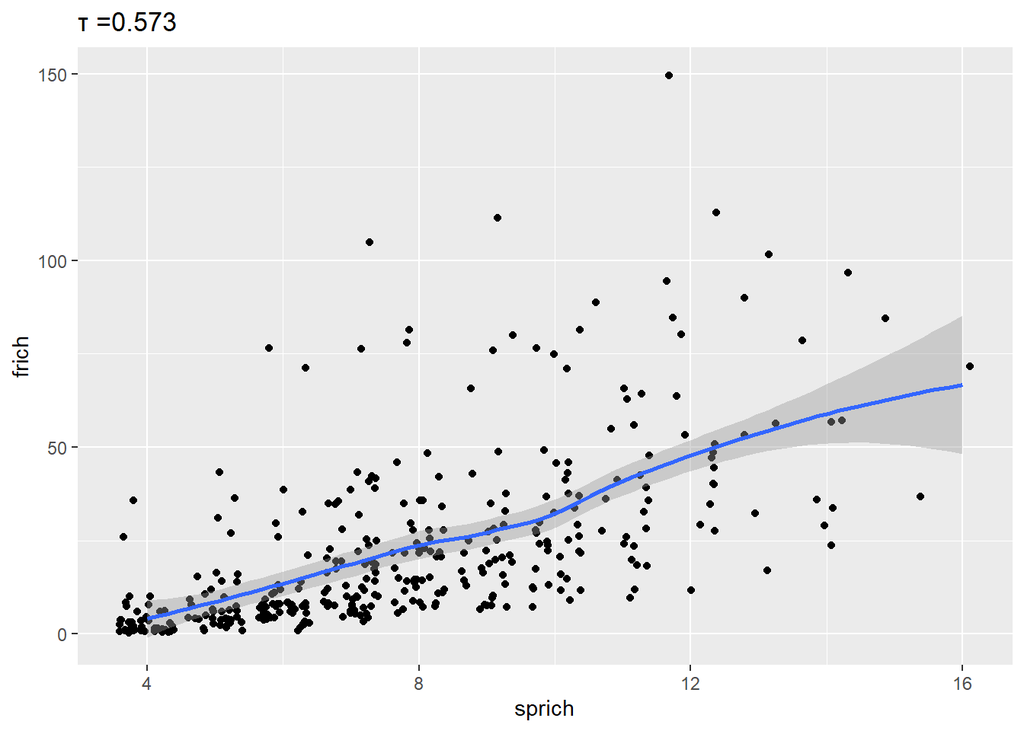

```r
nfk_div %>%
  filter(sprich > 1) %>%
  ggplot(aes(x = sprich, y = frich))+
  geom_jitter()+
  geom_smooth()+
  labs(title = paste("\u03c4 =", round(cor(nfk_div$sprich,
                                        nfk_div$frich,
                                        method = "kendall"), 3),
                     sep = ""))
```

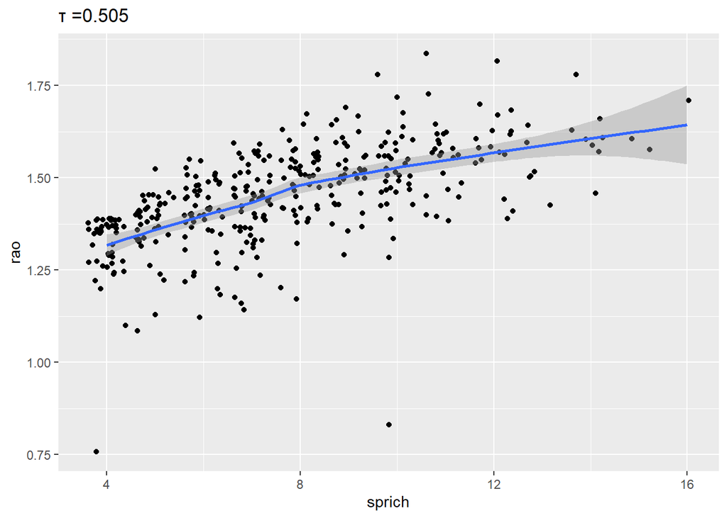

```r
nfk_div %>%
  filter(sprich > 1) %>%
  ggplot(aes(x = sprich, y = rao))+
  geom_jitter()+
  geom_smooth()+
  labs(title = paste("\u03c4 =", round(cor(nfk_div$sprich,
                                        nfk_div$rao,
                                        method = "kendall"), 3),
                     sep = ""))
```

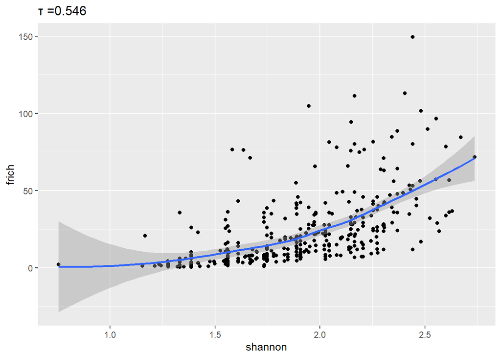

```r
nfk_div %>%
  filter(sprich > 1) %>%
  ggplot(aes(x = shannon, y = frich))+
  geom_jitter()+
  geom_smooth()+
  labs(title = paste("\u03c4 =", round(cor(nfk_div$shannon,
                                        nfk_div$frich,
                                        method = "kendall"), 3),
                     sep = ""))
```

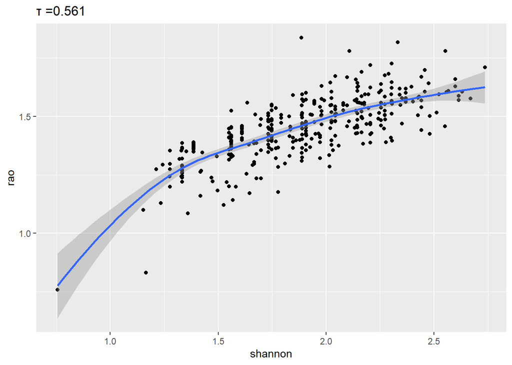

```r
nfk_div %>%
  filter(sprich > 1) %>%
  ggplot(aes(x = shannon, y = rao))+
  geom_jitter()+
  geom_smooth()+
  labs(title = paste("\u03c4 =", round(cor(nfk_div$shannon,
                                        nfk_div$rao,
                                        method = "kendall"), 3),
                     sep = ""))
```

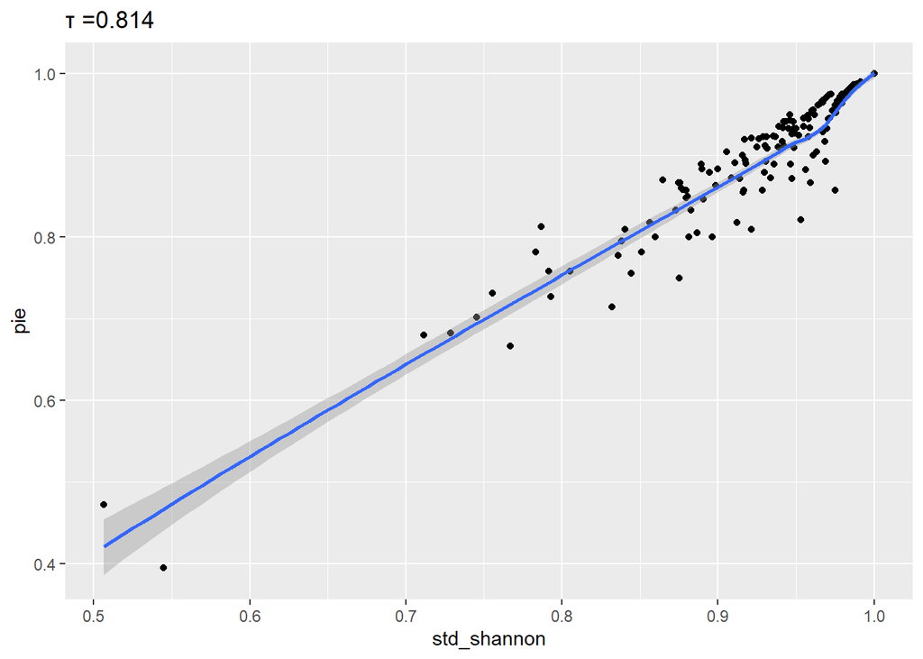

```r
nfk_div %>%
  filter(sprich > 1) %>%
  ggplot(aes(x = std_shannon, y = pie))+
  geom_jitter()+
  geom_smooth()+
  labs(title = paste("\u03c4 =", round(cor(nfk_div$std_shannon,
                                        nfk_div$pie,
                                        method = "kendall"), 3),
                     sep = ""))
```

## Building models

All models account for a day of observation as a cubic spline smoothing term in each model, assuming that observed diversity metrics are *some* functions of the day of observation (`Day`), and accounting for the random effect of location (`Point`).

Regarding the effect of time-of-day on diversity level, there are several scenarios considered:

- **intercept model** `[Metric] ~ (1 | Point) + s(Day)` assumes that the diversity metric is not related to time-of-day, therefore, this relationship could be described as an intercept model;
- **linear model** `[Metric] ~ 1 + (Daytime | Point) + s(Day)` assumes that the diversity metric is linearly related to time-of-day;
- **quadratic model** `[Metric] ~ 1 + (Daytime | Point) + (Daytime | Point)^2 + s(Day)` assumes that the relationship between time-of-day and diversity metric is hump-shaped;
- **cubic model** `[Metric] ~ 1 + (Daytime | Point) + (Daytime | Point)^2 + (Daytime | Point)^3 + s(Day)` assumes that the relationship between time-of-day and diversity metric is cubic;
- **generalized additive model** `[Metric] ~ 1 + s((Daytime | Point)) + s(Day)` assumes that the diversity metric is non-linearly related to time-of-day.

```r
nfk_modelbuild <- function(response, name){
  d_f <- data.frame(response = response,
                   Day = unlist(nfk_div$Day),
                   Point = unlist(nfk_div$Point),
                   Daytime = unlist(nfk_div$Daytime))
  poly0 <- gamm(response ~ 1 + s(Day, bs = "cr"),
                data = d_f,
                random = list(Point = ~ 1))
  poly1 <- gamm(response ~ poly(Daytime, 1) + s(Day, bs = "cr"),
                data = d_f,
                random = list(Point = ~ Daytime))
  poly2 <- gamm(response ~ poly(Daytime, 2) + s(Day, bs = "cr"),
                data = d_f,
                random = list(Point = ~ Daytime))
  poly3 <- gamm(response ~ poly(Daytime, 3) + s(Day, bs = "cr"),
                data = d_f,
                random = list(Point = ~ Daytime))
  gam0 <- gamm(response ~ s(Daytime, bs = "cr") + s(Day, bs = "cr"),
                data = d_f,
                random = list(Point = ~ Daytime))
  modelslist <- list(poly0,  poly1, poly2, poly3, gam0)
  names(modelslist) = c(paste(name, "~ Intercept | Point + s(Day)"),
                        paste(name, "~ LM | Point + s(Day)"),
                        paste(name, "~ poly(2) | Point + s(Day)"),
                        paste(name, "~ poly(3) | Point + s(Day)"),
                        paste(name, "~ GAM | Point + s(Day)"))
  return(modelslist)
}

models_sprich <- nfk_modelbuild(response = nfk_div$sprich,
                                name = "Species richness")
models_shannon <- nfk_modelbuild(response = nfk_div$shannon,
                                 name = "Shannon index")
models_std_shannon <- nfk_modelbuild(response = nfk_div$std_shannon,
                                     name = "Standardized Shannon")
models_pie <- nfk_modelbuild(response = nfk_div$pie,
                             name = "Hurlbert's PIE")

models_frich <- nfk_modelbuild(response = nfk_div$frich,
                               name = "Functional Richness")
models_feve <- nfk_modelbuild(response = nfk_div$feve,
                              name = "Functional Evenness")
models_rao <- nfk_modelbuild(response = nfk_div$rao,
                             name = "Rao's quadratic entropy")
models_pfd <- nfk_modelbuild(response = nfk_div$pfd,
                             name = "Weighted mean functional distinctiveness")
```

## Selection of the best model for each metric

Best model explaining a particular diversity metric is chosen based on the lowest AICc value for each subset.

```r
aicrank <- function(modlist){

  reduce_to_lme <- function(modelslist){
    test <- lapply(1:length(modelslist), function(i) modelslist[[i]][[1]])
    names(test) <- names(modelslist)
    return(test)
  }

  lmers <- reduce_to_lme(modlist)

  aicstat <- function(mod){
    aic <- AICc(mod)
    ll <- logLik(mod) %>% as.numeric()
    c(AICc = aic, logL = ll)
  }


  aictable <- do.call(rbind.data.frame, lapply(lmers, aicstat))
  colnames(aictable) <- c("AICc", "logL")

  aictable$name <- names(lmers)

  aictable$delta_AICc <- aictable$AICc - min(aictable$AICc)

  aictable$weight <- qpcR::akaike.weights(aictable$AICc)$weights

  aictable$df <- lapply(modlist, function(mod){
    round(sum(mod$gam$edf), 2)
  }) %>% unlist()

  aictable[,c("name", "AICc", "delta_AICc", "weight", "logL", "df")] %>%
    as_tibble() %>%
    arrange(delta_AICc)

}

models_ranking <- bind_rows(aicrank(models_sprich),
                    aicrank(models_shannon),
                    aicrank(models_std_shannon),
                    aicrank(models_pie),
                    aicrank(models_frich),
                    aicrank(models_pfd),
                    aicrank(models_feve),
                    aicrank(models_rao))

write_csv(models_ranking,
          file = "aic_table.csv")
```

Models ranking by AIC

| name | AICc | delta_AICc | weight | logL | df |
| --- | --- | --- | --- | --- | --- |
| Species richness ~ poly(2) \| Point + s(Day) | 1590.541 | 0.000 | 0.647 | -785.674 | 6.29 |
| Species richness ~ poly(3) \| Point + s(Day) | 1592.156 | 1.614 | 0.289 | -785.394 | 7.26 |
| Species richness ~ GAM \| Point + s(Day) | 1595.593 | 5.051 | 0.052 | -787.457 | 6.75 |
| Species richness ~ LM \| Point + s(Day) | 1598.356 | 7.815 | 0.013 | -790.663 | 5.27 |
| Species richness ~ Intercept \| Point + s(Day) | 1612.914 | 22.373 | 0.000 | -801.085 | 4.09 |
| Shannon index ~ poly(2) \| Point + s(Day) | 123.194 | 0.000 | 0.636 | -52.000 | 6.07 |
| Shannon index ~ poly(3) \| Point + s(Day) | 125.336 | 2.142 | 0.218 | -51.984 | 7.06 |
| Shannon index ~ GAM \| Point + s(Day) | 127.422 | 4.229 | 0.077 | -53.372 | 6.37 |
| Shannon index ~ LM \| Point + s(Day) | 127.614 | 4.420 | 0.070 | -55.291 | 5.07 |
| Shannon index ~ Intercept \| Point + s(Day) | 148.081 | 24.887 | 0.000 | -68.669 | 3.87 |
| Standardized Shannon ~ LM \| Point + s(Day) | -1090.886 | 0.000 | 0.324 | 553.959 | 3.00 |
| Standardized Shannon ~ poly(2) \| Point + s(Day) | -1090.469 | 0.417 | 0.263 | 554.831 | 4.00 |
| Standardized Shannon ~ poly(3) \| Point + s(Day) | -1090.047 | 0.839 | 0.213 | 555.707 | 5.00 |
| Standardized Shannon ~ Intercept \| Point + s(Day) | -1089.340 | 1.546 | 0.149 | 550.042 | 2.00 |
| Standardized Shannon ~ GAM \| Point + s(Day) | -1087.225 | 3.661 | 0.052 | 553.952 | 3.43 |
| Hurlbert’s PIE ~ LM \| Point + s(Day) | -938.813 | 0.000 | 0.507 | 477.922 | 3.00 |
| Hurlbert’s PIE ~ poly(2) \| Point + s(Day) | -937.377 | 1.435 | 0.248 | 478.285 | 4.00 |
| Hurlbert’s PIE ~ poly(3) \| Point + s(Day) | -936.392 | 2.420 | 0.151 | 478.880 | 5.01 |
| Hurlbert’s PIE ~ GAM \| Point + s(Day) | -935.166 | 3.646 | 0.082 | 477.922 | 3.00 |
| Hurlbert’s PIE ~ Intercept \| Point + s(Day) | -931.300 | 7.512 | 0.012 | 471.022 | 2.00 |
| Functional Richness ~ Intercept \| Point + s(Day) | 3300.794 | 0.000 | 0.605 | -1645.025 | 3.66 |
| Functional Richness ~ poly(2) \| Point + s(Day) | 3303.065 | 2.270 | 0.194 | -1641.936 | 5.79 |
| Functional Richness ~ poly(3) \| Point + s(Day) | 3304.546 | 3.752 | 0.093 | -1641.589 | 6.82 |
| Functional Richness ~ LM \| Point + s(Day) | 3304.838 | 4.044 | 0.080 | -1643.903 | 4.80 |
| Functional Richness ~ GAM \| Point + s(Day) | 3306.973 | 6.179 | 0.028 | -1643.147 | 5.82 |
| Weighted mean functional distinctiveness ~ Intercept \| Point + s(Day) | -1798.129 | 0.000 | 0.927 | 904.437 | 5.26 |
| Weighted mean functional distinctiveness ~ LM \| Point + s(Day) | -1792.049 | 6.081 | 0.044 | 904.540 | 6.27 |
| Weighted mean functional distinctiveness ~ poly(2) \| Point + s(Day) | -1789.981 | 8.148 | 0.016 | 904.587 | 7.25 |
| Weighted mean functional distinctiveness ~ GAM \| Point + s(Day) | -1788.401 | 9.728 | 0.007 | 904.540 | 6.27 |
| Weighted mean functional distinctiveness ~ poly(3) \| Point + s(Day) | -1787.815 | 10.315 | 0.005 | 904.591 | 8.26 |
| Functional Evenness ~ Intercept \| Point + s(Day) | -667.765 | 0.000 | 0.846 | 339.255 | 2.00 |
| Functional Evenness ~ LM \| Point + s(Day) | -663.206 | 4.560 | 0.087 | 340.118 | 3.00 |
| Functional Evenness ~ poly(2) \| Point + s(Day) | -661.594 | 6.171 | 0.039 | 340.394 | 4.00 |
| Functional Evenness ~ poly(3) \| Point + s(Day) | -659.597 | 8.168 | 0.014 | 340.482 | 5.00 |
| Functional Evenness ~ GAM \| Point + s(Day) | -659.558 | 8.207 | 0.014 | 340.118 | 3.00 |
| Rao’s quadratic entropy ~ Intercept \| Point + s(Day) | -481.539 | 0.000 | 0.531 | 246.141 | 3.16 |
| Rao’s quadratic entropy ~ LM \| Point + s(Day) | -480.267 | 1.272 | 0.281 | 248.649 | 4.25 |
| Rao’s quadratic entropy ~ poly(2) \| Point + s(Day) | -478.137 | 3.403 | 0.097 | 248.665 | 5.25 |
| Rao’s quadratic entropy ~ poly(3) \| Point + s(Day) | -476.646 | 4.893 | 0.046 | 249.007 | 6.29 |
| Rao’s quadratic entropy ~ GAM \| Point + s(Day) | -476.595 | 4.945 | 0.045 | 248.636 | 4.32 |

## Diversity metrics vs time-of-day

### Taxonomic diversity

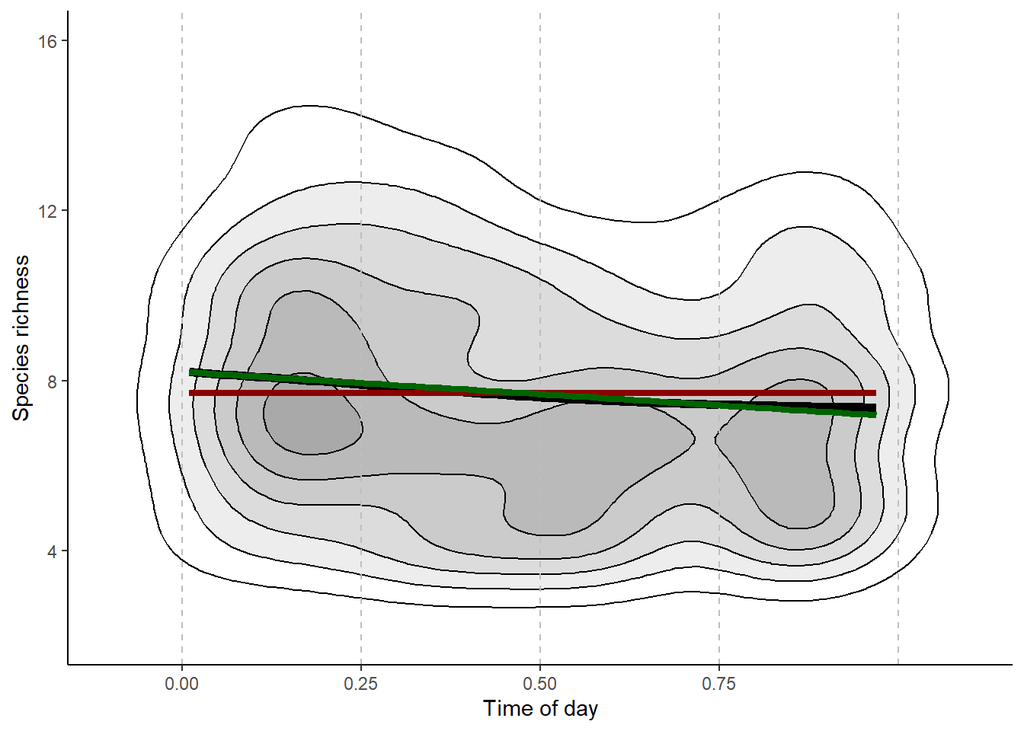

```r
findrange <- function(vec, p = 0.95, margin = 0.1){
  bottom <- quantile(vec, (1-p)/2)
  top <- quantile(vec, p+((1-p)/2))
  iql <- abs(bottom - top)
  c(bottom - margin*iql, top + margin*iql)
}

p_sprich <- ggplot(nfk_div, aes(x = Daytime, y = sprich)) +
  stat_density_2d(geom = "polygon", contour = TRUE,
                  aes(fill = after_stat(level)), colour = "black",
                  bins = 7, show.legend = F)
plot_lims <- ggplot_build(p_sprich)$panel$ranges[[1]][c("x.range", "y.range")]

p_sprich <- p_sprich +
  scale_x_continuous(limits = c(-0.1, 1.1),
                     breaks = c(0, 0.25, 0.5, 0.75)) +
  scale_y_continuous(limits = findrange(nfk_div$sprich, 0.95, 0.2)) +
  coord_cartesian(xlim = plot_lims$x.range, ylim = plot_lims$y.range) +
  scale_fill_gradient(low="white", high="darkgrey")+
  theme_classic()+
  geom_smooth(method = "gam", formula = y ~ s(x, bs = "cs"), color = "black", se = F,
              lwd = 2, linetype = "solid")+
  geom_vline(xintercept = c(seq(0, 1, 0.25)), color = "grey", linetype = "dashed")+
  labs(x = "Time of day", y = "Species richness")

p_sprich +
  geom_smooth(method = "lm", formula = y ~ 1, color = "darkred", se = F, lwd = 1.5,
              linetype = "solid", show.legend = T)+
  geom_smooth(method = "lm", color = "darkgreen", se = F, lwd = 1.5, linetype = "solid")
```

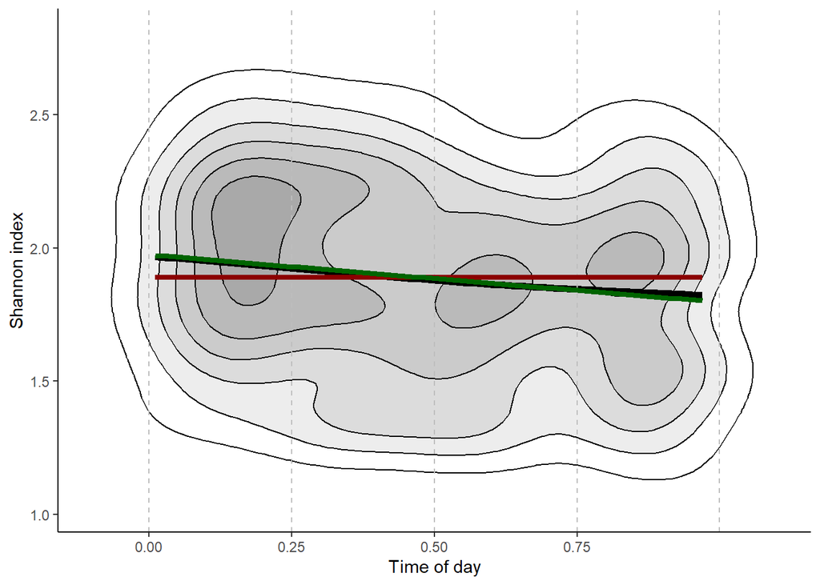

```r
p_shannon <- ggplot(nfk_div, aes(x = Daytime, y = shannon)) +
  stat_density_2d(geom = "polygon", contour = TRUE,
                  aes(fill = after_stat(level)), colour = "black",
                  bins = 7, show.legend = F)
plot_lims <- ggplot_build(p_shannon)$panel$ranges[[1]][c("x.range", "y.range")]

p_shannon <- p_shannon +
  scale_x_continuous(limits = c(-0.1, 1.1),
                     breaks = c(0, 0.25, 0.5, 0.75)) +
  scale_y_continuous(limits = findrange(nfk_div$shannon, 0.95, 0.2)) +
  coord_cartesian(xlim = plot_lims$x.range, ylim = plot_lims$y.range) +
  scale_fill_gradient(low="white", high="darkgrey")+
  theme_classic()+
  geom_smooth(method = "gam", formula = y ~ s(x, bs = "cs"), color = "black", se = F,
              lwd = 2, linetype = "solid")+
  geom_vline(xintercept = c(seq(0, 1, 0.25)), color = "grey", linetype = "dashed")+
  labs(x = "Time of day", y = "Shannon index")

p_shannon +
  geom_smooth(method = "lm", formula = y ~ 1, color = "darkred", se = F, lwd = 1.5,
              linetype = "solid", show.legend = T)+
  geom_smooth(method = "lm", color = "darkgreen", se = F, lwd = 1.5, linetype = "solid")
```

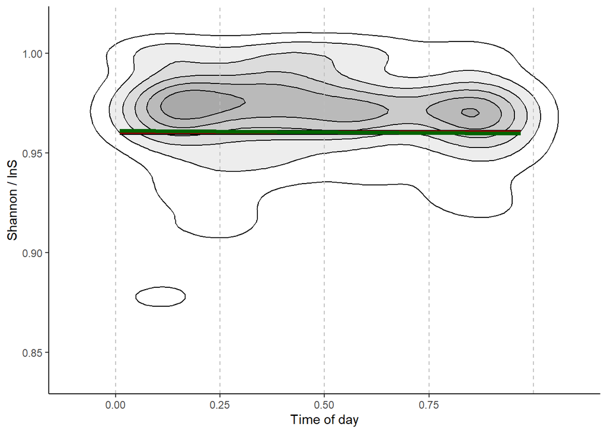

```r
p_std_shannon <- ggplot(nfk_div, aes(x = Daytime, y = std_shannon)) +
  stat_density_2d(geom = "polygon", contour = TRUE,
                  aes(fill = after_stat(level)), colour = "black",
                  bins = 7, show.legend = F)
plot_lims <- ggplot_build(p_std_shannon)$panel$ranges[[1]][c("x.range", "y.range")]

p_std_shannon <- p_std_shannon +
  scale_x_continuous(limits = c(-0.1, 1.1),
                     breaks = c(0, 0.25, 0.5, 0.75)) +
  scale_y_continuous(limits = findrange(nfk_div$std_shannon, 0.9, 0.1)) +
  coord_cartesian(xlim = plot_lims$x.range, ylim = plot_lims$y.range) +
  scale_fill_gradient(low="white", high="darkgrey")+
  theme_classic()+
  geom_smooth(method = "gam", formula = y ~ s(x, bs = "cs"), color = "black", se = F,
              lwd = 2, linetype = "solid")+
  geom_vline(xintercept = c(seq(0, 1, 0.25)), color = "grey", linetype = "dashed")+
  labs(x = "Time of day", y = "Shannon / lnS")

p_std_shannon +
  geom_smooth(method = "lm", formula = y ~ 1, color = "darkred", se = F, lwd = 1.5,
              linetype = "solid", show.legend = T)+
  geom_smooth(method = "lm", color = "darkgreen", se = F, lwd = 1.5, linetype = "solid")
```

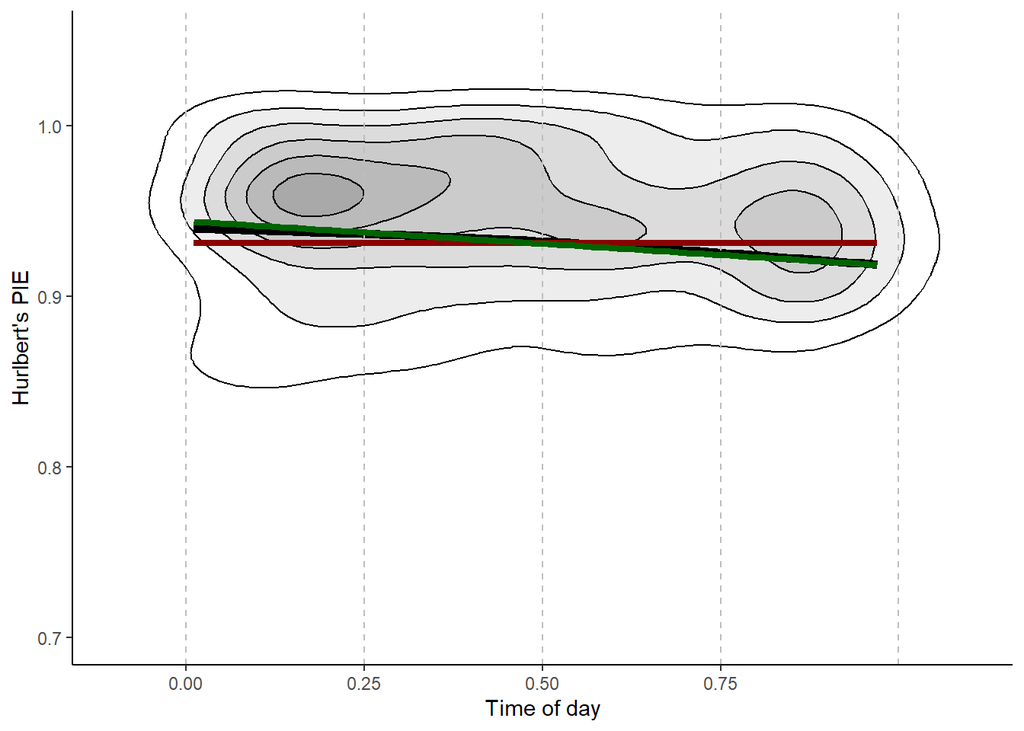

```r
p_pie <- ggplot(nfk_div, aes(x = Daytime, y = pie)) +
  stat_density_2d(geom = "polygon", contour = TRUE,
                  aes(fill = after_stat(level)), colour = "black",
                  bins = 7, show.legend = F)
plot_lims <- ggplot_build(p_pie)$panel$ranges[[1]][c("x.range", "y.range")]

p_pie <- p_pie +
  scale_x_continuous(limits = c(-0.1, 1.1),
                     breaks = c(0, 0.25, 0.5, 0.75)) +
  scale_y_continuous(limits = findrange(nfk_div$pie, 0.95, 0.2)) +
  coord_cartesian(xlim = plot_lims$x.range, ylim = plot_lims$y.range) +
  scale_fill_gradient(low="white", high="darkgrey")+
  theme_classic()+
  geom_smooth(method = "gam", formula = y ~ s(x, bs = "cs"), color = "black", se = F,
              lwd = 2, linetype = "solid")+
  geom_vline(xintercept = c(seq(0, 1, 0.25)), color = "grey", linetype = "dashed")+
  labs(x = "Time of day", y = "Hurlbert's PIE")

p_pie +
  geom_smooth(method = "lm", formula = y ~ 1, color = "darkred", se = F, lwd = 1.5,
              linetype = "solid", show.legend = T)+
  geom_smooth(method = "lm", color = "darkgreen", se = F, lwd = 1.5, linetype = "solid")
```

### Functional diversity

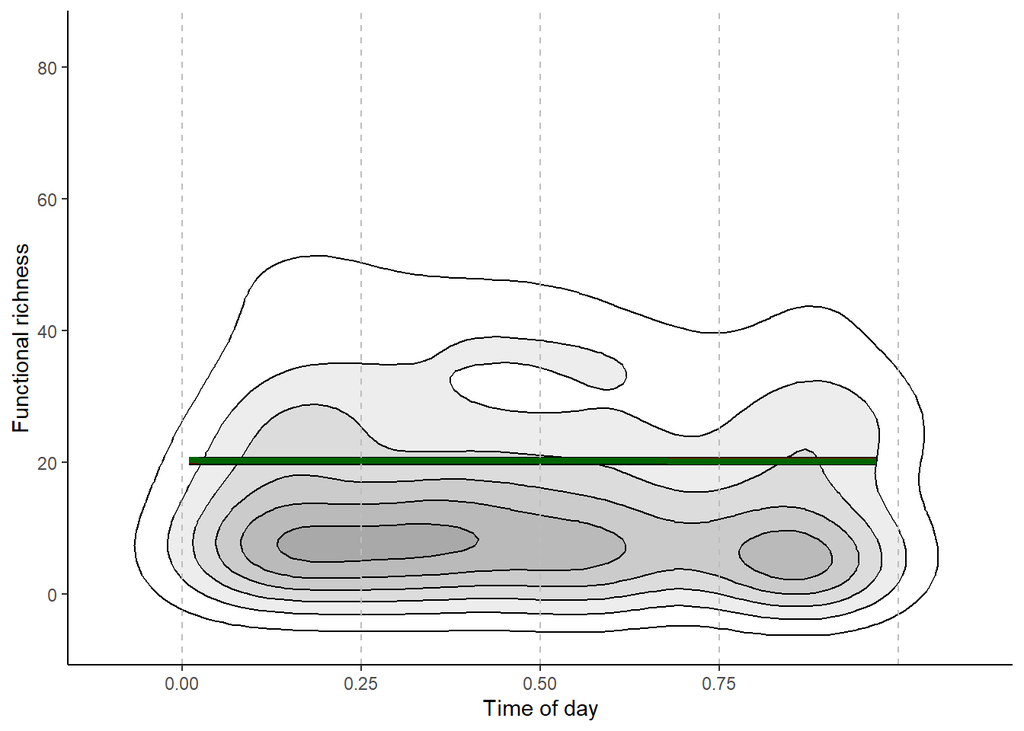

```r
p_frich <- ggplot(nfk_div, aes(x = Daytime, y = frich)) +
  stat_density_2d(geom = "polygon", contour = TRUE,
                  aes(fill = after_stat(level)), colour = "black",
                  bins = 7, show.legend = F)
plot_lims <- ggplot_build(p_frich)$panel$ranges[[1]][c("x.range", "y.range")]

p_frich <- p_frich +
  scale_x_continuous(limits = c(-0.1, 1.1),
                     breaks = c(0, 0.25, 0.5, 0.75)) +
  scale_y_continuous(limits = findrange(nfk_div$frich, 0.9, 0.1)) +
  coord_cartesian(xlim = plot_lims$x.range, ylim = plot_lims$y.range) +
  scale_fill_gradient(low="white", high="darkgrey")+
  theme_classic()+
  geom_smooth(method = "gam", formula = y ~ s(x, bs = "cs"), color = "black", se = F,
              lwd = 2, linetype = "solid")+
  geom_vline(xintercept = c(seq(0, 1, 0.25)), color = "grey", linetype = "dashed")+
  labs(x = "Time of day", y = "Functional richness")

p_frich +
  geom_smooth(method = "lm", formula = y ~ 1, color = "darkred", se = F, lwd = 1.5,
              linetype = "solid", show.legend = T)+
  geom_smooth(method = "lm", color = "darkgreen", se = F, lwd = 1.5, linetype = "solid")
```

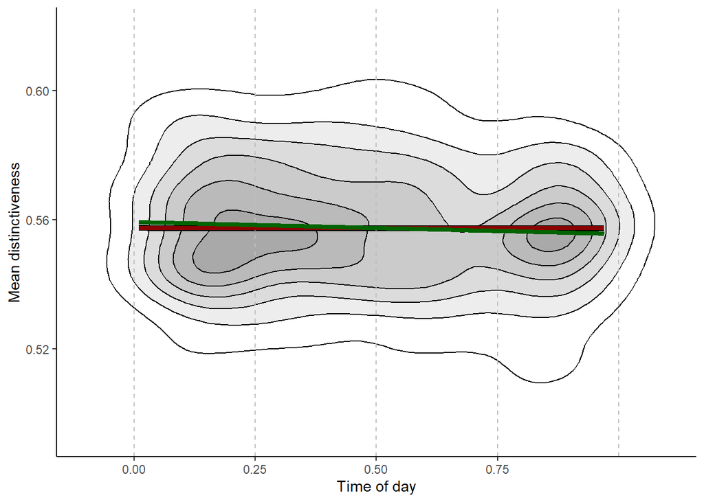

```r
p_pfd <- ggplot(nfk_div, aes(x = Daytime, y = pfd)) +
  stat_density_2d(geom = "polygon", contour = TRUE,
                  aes(fill = after_stat(level)), colour = "black",
                  bins = 7, show.legend = F)
plot_lims <- ggplot_build(p_pfd)$panel$ranges[[1]][c("x.range", "y.range")]

p_pfd <- p_pfd +
  scale_x_continuous(limits = c(-0.1, 1.1),
                     breaks = c(0, 0.25, 0.5, 0.75)) +
  scale_y_continuous(limits = findrange(nfk_div$pfd, 0.95, 0.2)) +
  coord_cartesian(xlim = plot_lims$x.range, ylim = plot_lims$y.range) +
  scale_fill_gradient(low="white", high="darkgrey")+
  theme_classic() +
  geom_smooth(method = "gam", formula = y ~ s(x, bs = "cs"), color = "black", se = F,
              lwd = 2, linetype = "solid")+
  geom_vline(xintercept = c(seq(0, 1, 0.25)), color = "grey", linetype = "dashed")+
  labs(x = "Time of day", y = "Mean distinctiveness")

p_pfd +
  geom_smooth(method = "lm", formula = y ~ 1, color = "darkred", se = F, lwd = 1.5,
              linetype = "solid", show.legend = T)+
  geom_smooth(method = "lm", color = "darkgreen", se = F, lwd = 1.5, linetype = "solid")
```

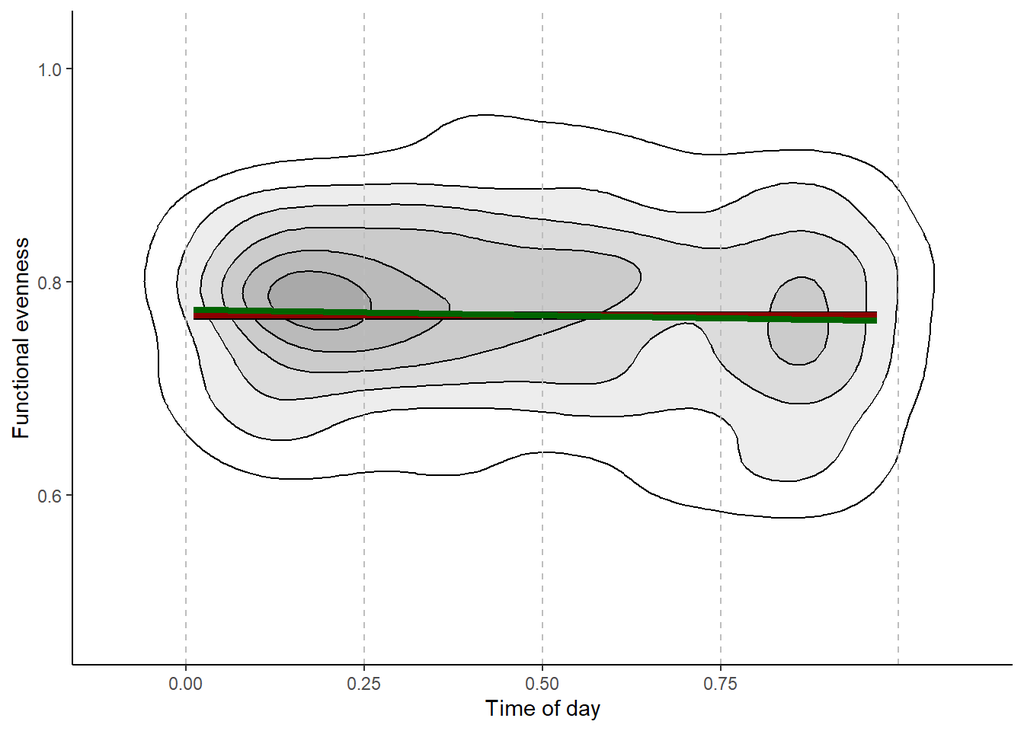

```r
p_feve <- ggplot(nfk_div, aes(x = Daytime, y = feve)) +
  stat_density_2d(geom = "polygon", contour = TRUE,
                  aes(fill = after_stat(level)), colour = "black",
                  bins = 7, show.legend = F)
plot_lims <- ggplot_build(p_feve)$panel$ranges[[1]][c("x.range", "y.range")]

p_feve <- p_feve +
  scale_x_continuous(limits = c(-0.1, 1.1),
                     breaks = c(0, 0.25, 0.5, 0.75)) +
  scale_y_continuous(limits = findrange(nfk_div$feve, 0.95, 0.2)) +
  coord_cartesian(xlim = plot_lims$x.range, ylim = plot_lims$y.range) +
  scale_fill_gradient(low="white", high="darkgrey")+
  theme_classic()+
  geom_smooth(method = "gam", formula = y ~ s(x, bs = "cs"), color = "black", se = F,
              lwd = 2, linetype = "solid")+
  geom_vline(xintercept = c(seq(0, 1, 0.25)), color = "grey", linetype = "dashed")+
  labs(x = "Time of day", y = "Functional evenness")

p_feve +
  geom_smooth(method = "lm", formula = y ~ 1, color = "darkred", se = F, lwd = 1.5,
              linetype = "solid", show.legend = T)+
  geom_smooth(method = "lm", color = "darkgreen", se = F, lwd = 1.5, linetype = "solid")
```

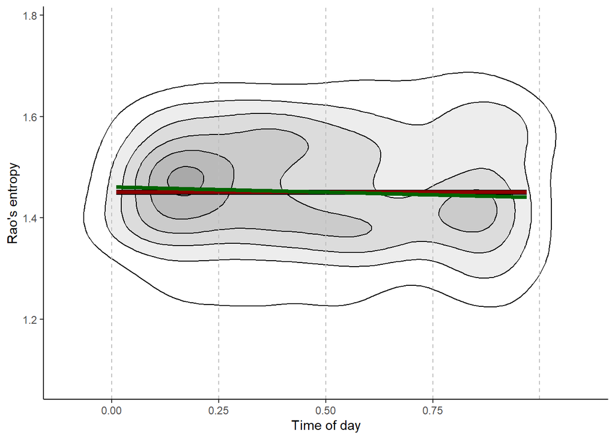

```r
p_rao <- ggplot(nfk_div, aes(x = Daytime, y = rao)) +
  stat_density_2d(geom = "polygon", contour = TRUE,
                  aes(fill = after_stat(level)), colour = "black",
                  bins = 7, show.legend = F)
plot_lims <- ggplot_build(p_rao)$panel$ranges[[1]][c("x.range", "y.range")]

p_rao <- p_rao +
  scale_x_continuous(limits = c(-0.1, 1.1),
                     breaks = c(0, 0.25, 0.5, 0.75)) +
  scale_y_continuous(limits = findrange(nfk_div$rao, 0.95, 0.2)) +
  coord_cartesian(xlim = plot_lims$x.range, ylim = plot_lims$y.range) +
  scale_fill_gradient(low="white", high="darkgrey")+
  theme_classic()+
  geom_smooth(method = "gam", formula = y ~ s(x, bs = "cs"), color = "black", se = F,
              lwd = 2, linetype = "solid")+
  geom_vline(xintercept = c(seq(0, 1, 0.25)), color = "grey", linetype = "dashed")+
  labs(x = "Time of day", y = "Rao's entropy")

p_rao +
  geom_smooth(method = "lm", formula = y ~ 1, color = "darkred", se = F, lwd = 1.5,
              linetype = "solid", show.legend = T)+
  geom_smooth(method = "lm", color = "darkgreen", se = F, lwd = 1.5, linetype = "solid")
```